# Lorem ipsum dolor sit amet

At first,lets’ check whether the authors tend to speak more complex sentences over time and results in a more clear category.

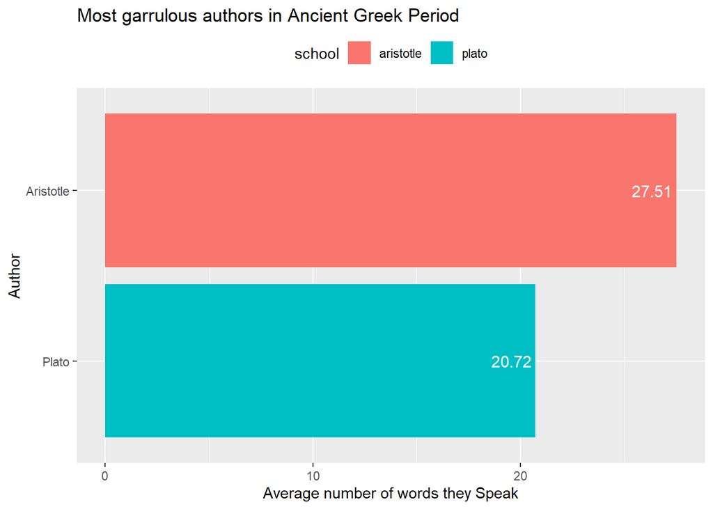

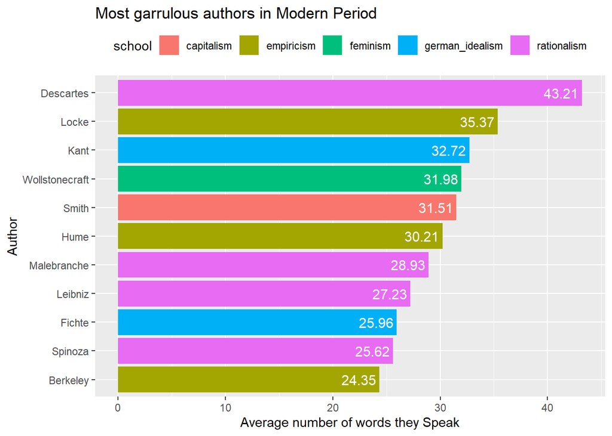

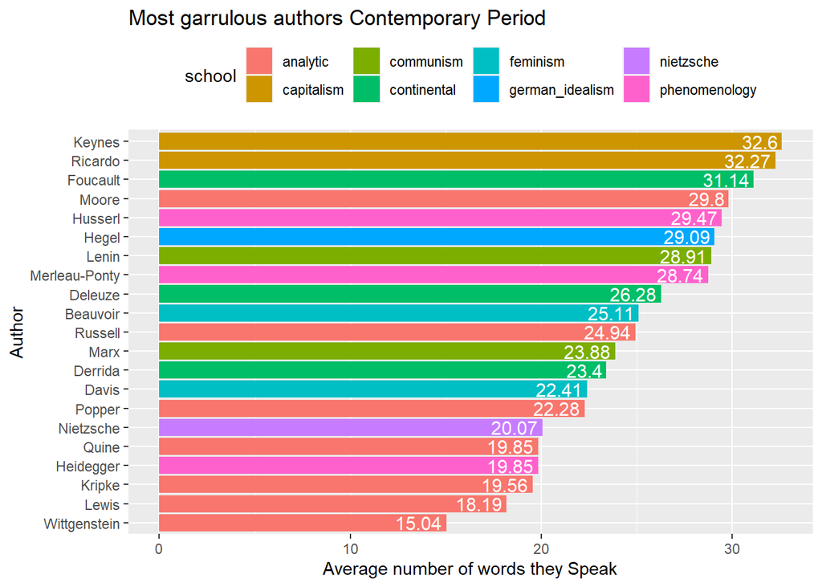

From the results above, it is obvious that each author have their own habit of the length they speak, When we compare the capitalism author Smith in modern philosophy, with other capitalism authors in contemporary philosophy, they all seems to speak around 32 words to express their thoughts. Capitalism philosopher in contemporary prefer to speak more explicitly, while analytic philosopher speak more reflectively.In addition, Descartes is an outlier from the rationalism in the aspect of sentence length.

[figure not shown]

Now we are more interested in how does their philosophy topic evolves each period, we wish to observe some most frequently used words in each period.

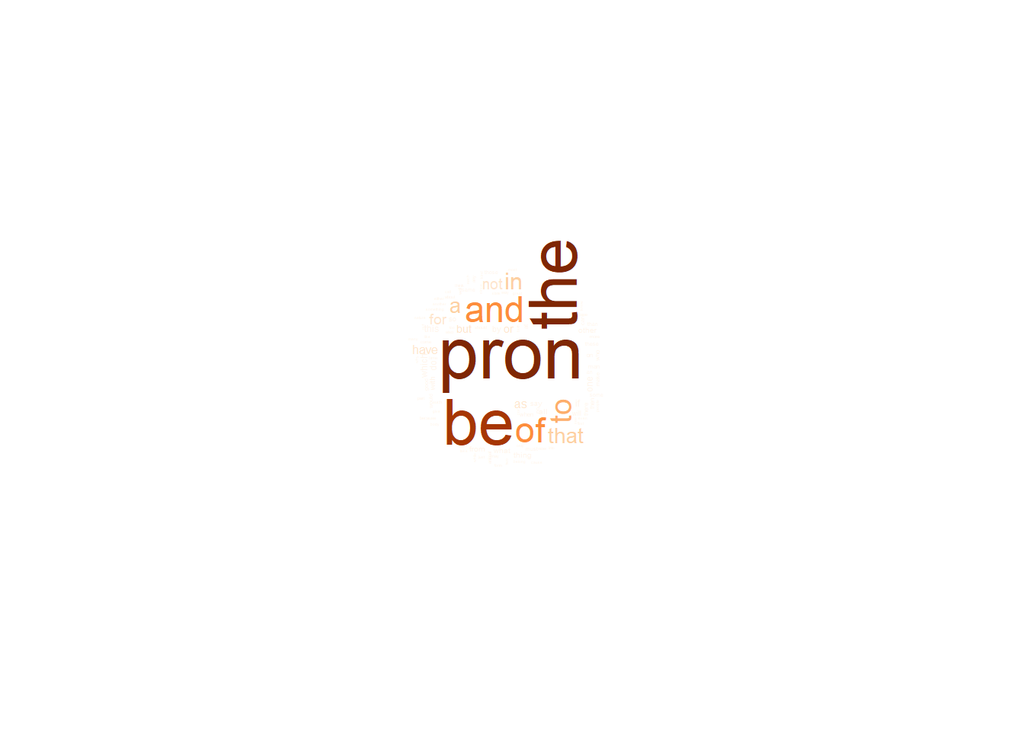

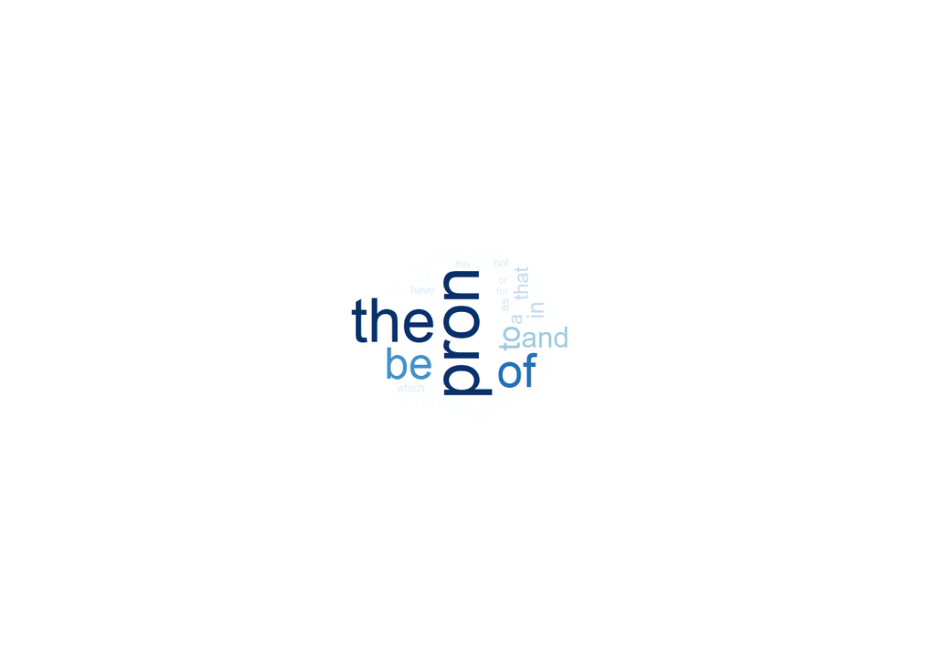

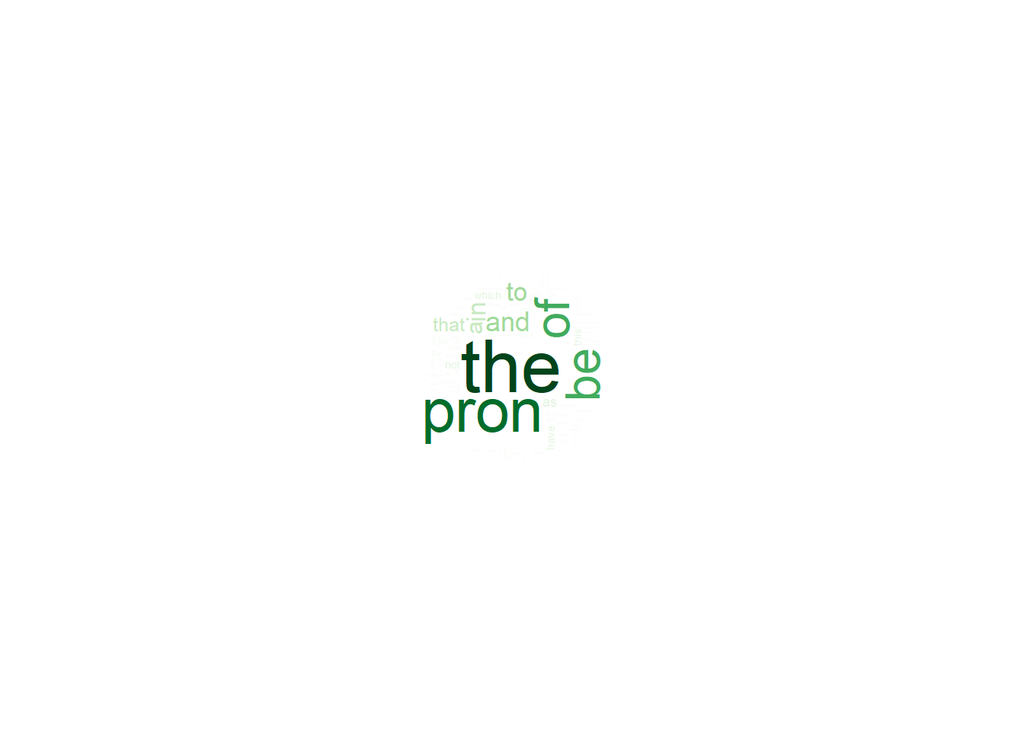

However,in this three stages. Most frequent words are “the, be, pron” which are quite uninformative, So I cleaned those stop words and reorganized their sentence with key words. Usually, transfer those key words to the noun are more explanatory.

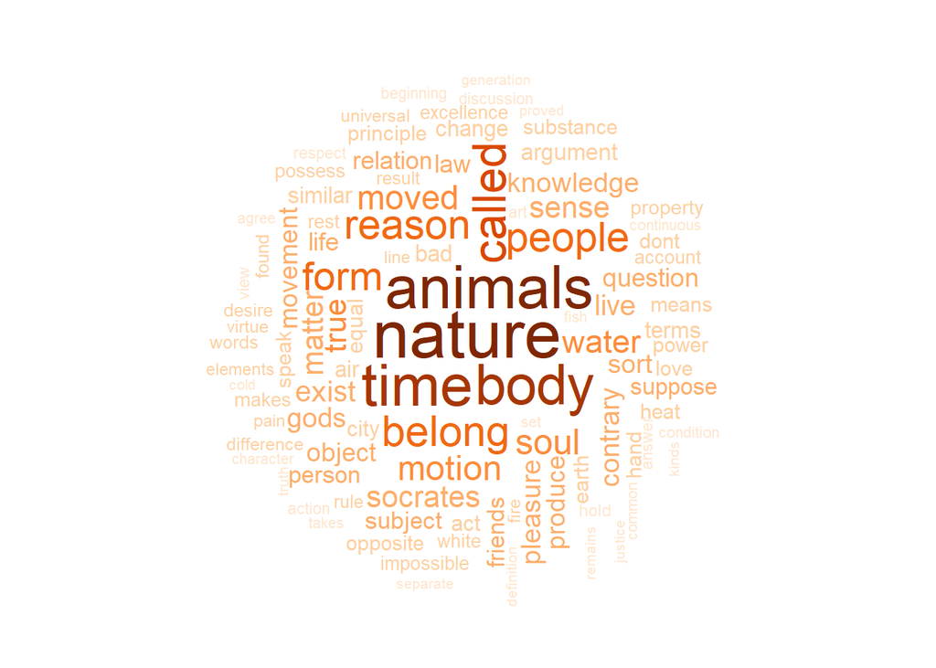

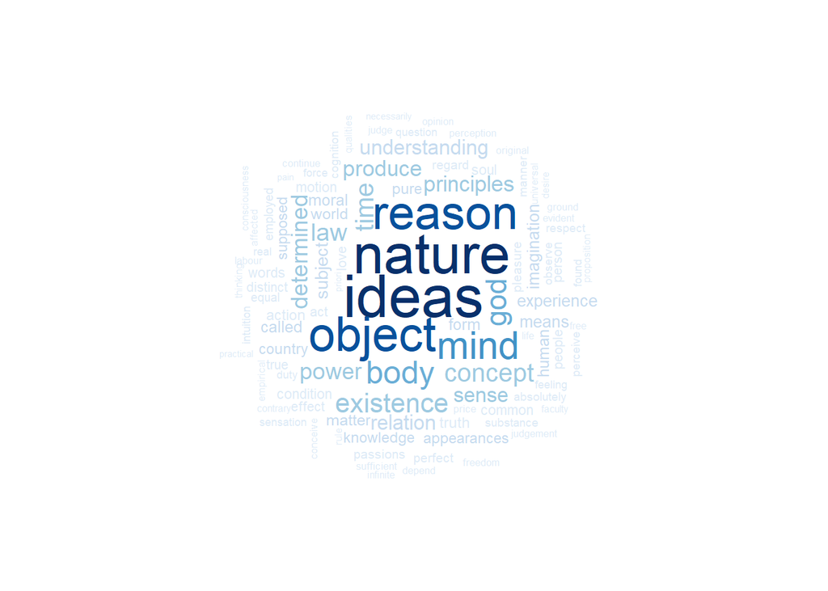

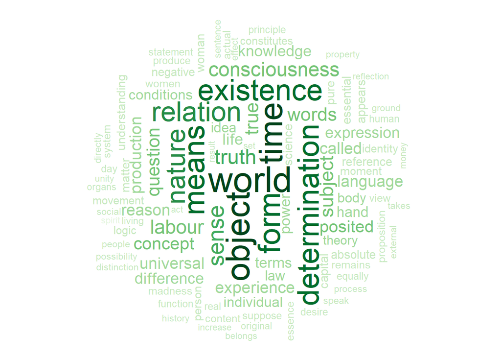